# Problem Set #4

Kevin McAlister

2022-10-27

```r
# data read-in
cancer_train <- read.csv("cancerTrain.csv")
cancer_test <- read.csv("cancerTest.csv")
wine_train <- read.csv("wineTrain.csv")
```

Collaborators: Billy Ge, Latifa Tan, Annie Luo

## Problem 1: The Multivariate Normal Distribution (20 pts.)

$$\begin{eqnarray}
\frac{\partial \ell \ell}{\partial \mu} &=& - \frac{1}{2} \sum
\limits_{i = 1}^N [\frac{\partial(\boldsymbol x_i - \boldsymbol \mu
)' \Sigma^{-1} (\boldsymbol{x}_i - \boldsymbol \mu)}{\partial
\mu}]\\
&=& - \frac{1}{2} \sum \limits_{i = 1}^N
[2*\Sigma^{-1}*(\boldsymbol{x}_i - \boldsymbol \mu)*(-1)]\\
&=& \sum \limits_{i = 1}^N \Sigma^{-1}*(\boldsymbol{x}_i -
\boldsymbol \mu)\\
0 &=& \Sigma^{-1}*\sum \limits_{i = 1}^N (\boldsymbol{x}_i -
\boldsymbol \mu)\\
\Sigma* 0 &=& \Sigma\Sigma^{-1}*\sum \limits_{i = 1}^N
(\boldsymbol{x}_i - \boldsymbol \mu)\\
0 &=& \sum \limits_{i = 1}^N (\boldsymbol{x}_i - \boldsymbol
\mu)\\
0 &=& \sum \limits_{i = 1}^N \boldsymbol{x}_i - N*\mu\\
\hat{\mu} &=& \frac{1}{N} \sum \limits_{i = 1}^N
\boldsymbol{x}_i
\end{eqnarray}$$

$$\begin{eqnarray}
\frac{\partial \ell \ell}{\partial \Sigma^{-1}} &=& -
\frac{N}{2}*[\frac{\partial \log \text{det}(\Sigma)}{\partial
\Sigma^{-1}}] -\frac{1}{2} \sum \limits_{i = 1}^N [\frac{\partial
(\boldsymbol x_i - \boldsymbol \mu )' \Sigma^{-1} (\boldsymbol{x}_i
- \boldsymbol \mu)}{\partial \Sigma^{-1}}]\\
&=& - \frac{N}{2}*(-\Sigma) - \frac{1}{2} \sum \limits_{i =
1}^N[(\boldsymbol{x}_i - \boldsymbol \mu)(\boldsymbol{x}_i - \boldsymbol
\mu)']\\
N*\Sigma &=& \sum \limits_{i = 1}^N[(\boldsymbol{x}_i -
\boldsymbol \mu)(\boldsymbol{x}_i - \boldsymbol \mu)']\\
\hat{\Sigma} &=& \frac{1}{N}\sum \limits_{i =
1}^N[(\boldsymbol{x}_i - \boldsymbol \mu)(\boldsymbol{x}_i - \boldsymbol
\mu)']
\end{eqnarray}$$

## Problem 2: Cancer Data (40 Points)

### Part 1 (15 points)

```r
p2p1_df1 <- data.frame(matrix(nrow = 10, ncol = 10))

malignant_df <- cancer_train %>%
    filter(Malignant == 1)
malignant_prob <- nrow(malignant_df)/500
non_malignant_df <- cancer_train %>%
    filter(Malignant == 0)
non_malignant_prob <- nrow(non_malignant_df)/500

for (i in 1:10) {
    for (j in 1:10) {
        temp_df1 <- malignant_df %>%
            filter(UCellSize == i & SECellSize == j)
        temp_df2 <- non_malignant_df %>%
            filter(UCellSize == i & SECellSize == j)

        if (nrow(temp_df1) == 0) {
            p2p1_df1[i, j] <- NA
            next
        }

        result_numerator <- nrow(temp_df1)/nrow(malignant_df) *
            malignant_prob
        result_denominator <- result_numerator + nrow(temp_df2)/nrow(non_malignant_df) *
            non_malignant_prob
        p2p1_df1[i, j] <- result_numerator/result_denominator
    }
}

p2p1_df1
```

| X1 | X2 | X3 | X4 | X5 | X6 | X7 | X8 | X9 | X10 |
| --- | --- | --- | --- | --- | --- | --- | --- | --- | --- |
| 0.03333333 | 0.004975124 | NA | 0.4000000 | NA | NA | NA | NA | NA | NA |
| NA | 0.086956522 | 0.6666667 | NA | 0.5 | 1.0 | NA | NA | NA | NA |
| NA | 0.294117647 | 0.5625000 | 0.3333333 | 0.8 | 1.0 | NA | 1 | NA | 1 |
| NA | 0.888888889 | 0.8333333 | 0.8000000 | 1.0 | 0.8 | NA | NA | 1 | NA |
| NA | 1.000000000 | 1.0000000 | 1.0000000 | 1.0 | 1.0 | NA | 1 | NA | 1 |
| NA | 1.000000000 | 1.0000000 | 1.0000000 | 1.0 | 1.0 | NA | 1 | NA | 1 |
| NA | NA | NA | 1.0000000 | 0.8 | 1.0 | 1 | 1 | NA | 1 |
| NA | NA | 0.8000000 | 1.0000000 | 1.0 | 1.0 | NA | 1 | NA | 1 |
| NA | NA | 1.0000000 | NA | NA | 1.0 | NA | NA | NA | 1 |
| NA | 1.000000000 | 1.0000000 | 1.0000000 | 1.0 | 1.0 | 1 | 1 | 1 | 1 |

```r
p2p1_df2 <- data.frame(matrix(nrow = 10, ncol = 10))

for (i in 1:10) {
    for (j in 1:10) {
        if (is.na(p2p1_df1[i, j])) {
            next
        } else if (p2p1_df1[i, j] > 0.5) {
            p2p1_df2[i, j] <- 1
        } else if (p2p1_df1[i, j] < 0.5) {
            p2p1_df2[i, j] <- 0
        } else if (p2p1_df1[i, j] == 0.5) {
            p2p1_df2[i, j] <- 1
        }
    }
}

p2p1_df2
```

| X1 | X2 | X3 | X4 | X5 | X6 | X7 | X8 | X9 | X10 |
| --- | --- | --- | --- | --- | --- | --- | --- | --- | --- |
| 0 | 0 | NA | 0 | NA | NA | NA | NA | NA | NA |
| NA | 0 | 1 | NA | 1 | 1 | NA | NA | NA | NA |
| NA | 0 | 1 | 0 | 1 | 1 | NA | 1 | NA | 1 |
| NA | 1 | 1 | 1 | 1 | 1 | NA | NA | 1 | NA |
| NA | 1 | 1 | 1 | 1 | 1 | NA | 1 | NA | 1 |
| NA | 1 | 1 | 1 | 1 | 1 | NA | 1 | NA | 1 |
| NA | NA | NA | 1 | 1 | 1 | 1 | 1 | NA | 1 |
| NA | NA | 1 | 1 | 1 | 1 | NA | 1 | NA | 1 |
| NA | NA | 1 | NA | NA | 1 | NA | NA | NA | 1 |
| NA | 1 | 1 | 1 | 1 | 1 | 1 | 1 | 1 | 1 |

There are many classes that have probability of cancer occurrence of 1. They typically take place when both predictors have large values. Hence, the general relationship between the two predictors and the probability that a cell is cancerous is positive, meaning that the probability of cancer occurrence increases as the values of UCellSize and SECellSize increases.

It does appear that we’ve missed some information by treating this problem in an unordered discrete fashion, because there are many NA entries in our probability lookup table. The given (UCellSize, SECellSize) pair has NA probability of cancer occurrence and NA Bayes’ classifier when there is no such observation pair given the response variable is malignant in the training dataset.

### Part 2 (15 points)

```r
# logistic regression classifier
p2p2_logistic <- glm(data = cancer_train, formula = Malignant ~
    UCellSize + SECellSize, family = binomial(link = "logit"))

UCellSize <- rep(seq(1, 10, 1), 10)
SECellSize <- rep(seq(1, 10, 1), each = 10)
p2p2_df <- data.frame(UCellSize, SECellSize)
p2p2_df$logistic <- predict(p2p2_logistic, type = "response",
    newdata = p2p2_df)

p2p2_df1 <- data.frame(matrix(nrow = 10, ncol = 10))
for (i in 1:10) {
    for (j in 1:10) {
        temp <- p2p2_df %>%
            filter(UCellSize == i, SECellSize == j)
        p2p2_df1[i, j] <- temp[1, "logistic"]
    }
}

p2p2_df1
```

| X1 | X2 | X3 | X4 | X5 | X6 | X7 | X8 | X9 | X10 |
| --- | --- | --- | --- | --- | --- | --- | --- | --- | --- |
| 0.02349457 | 0.03536289 | 0.05290173 | 0.07843197 | 0.1147898 | 0.1649842 | 0.2313900 | 0.3144585 | 0.4113869 | 0.5157166 |
| 0.07932851 | 0.11604955 | 0.16669114 | 0.23359181 | 0.3171246 | 0.4143780 | 0.5187977 | 0.6216008 | 0.7145264 | 0.7922583 |
| 0.23580811 | 0.31980272 | 0.41737551 | 0.52187738 | 0.6244987 | 0.7170366 | 0.7942819 | 0.8547128 | 0.8996350 | 0.9317761 |
| 0.52495540 | 0.62738779 | 0.71953346 | 0.79629074 | 0.8562384 | 0.9007436 | 0.9325563 | 0.9546857 | 0.9697892 | 0.9799643 |
| 0.79828499 | 0.85775063 | 0.90184137 | 0.93332826 | 0.9552165 | 0.9701487 | 0.9802052 | 0.9869195 | 0.9913763 | 0.9943234 |
| 0.93409199 | 0.95574137 | 0.97050395 | 0.98044319 | 0.9870778 | 0.9914812 | 0.9943926 | 0.9963127 | 0.9975769 | 0.9984084 |
| 0.98067838 | 0.98723426 | 0.99158479 | 0.99446100 | 0.9963578 | 0.9976066 | 0.9984279 | 0.9989676 | 0.9993222 | 0.9995551 |
| 0.99452855 | 0.99640227 | 0.99763585 | 0.99844712 | 0.9989803 | 0.9993305 | 0.9995605 | 0.9997115 | 0.9998106 | 0.9998757 |
| 0.99846614 | 0.99899278 | 0.99933872 | 0.99956590 | 0.9997151 | 0.9998130 | 0.9998772 | 0.9999194 | 0.9999471 | 0.9999653 |
| 0.99957122 | 0.99971855 | 0.99981526 | 0.99987875 | 0.9999204 | 0.9999478 | 0.9999657 | 0.9999775 | 0.9999852 | 0.9999903 |

```r
p2p2_df2 <- data.frame(matrix(nrow = 10, ncol = 10))
for (i in 1:10) {
    for (j in 1:10) {
        if (p2p2_df1[i, j] > 0.5) {
            p2p2_df2[i, j] <- 1
        } else {
            p2p2_df2[i, j] <- 0
        }
    }
}

p2p2_df2
```

| X1 | X2 | X3 | X4 | X5 | X6 | X7 | X8 | X9 | X10 |
| --- | --- | --- | --- | --- | --- | --- | --- | --- | --- |
| 0 | 0 | 0 | 0 | 0 | 0 | 0 | 0 | 0 | 1 |
| 0 | 0 | 0 | 0 | 0 | 0 | 1 | 1 | 1 | 1 |
| 0 | 0 | 0 | 1 | 1 | 1 | 1 | 1 | 1 | 1 |
| 1 | 1 | 1 | 1 | 1 | 1 | 1 | 1 | 1 | 1 |
| 1 | 1 | 1 | 1 | 1 | 1 | 1 | 1 | 1 | 1 |
| 1 | 1 | 1 | 1 | 1 | 1 | 1 | 1 | 1 | 1 |
| 1 | 1 | 1 | 1 | 1 | 1 | 1 | 1 | 1 | 1 |
| 1 | 1 | 1 | 1 | 1 | 1 | 1 | 1 | 1 | 1 |
| 1 | 1 | 1 | 1 | 1 | 1 | 1 | 1 | 1 | 1 |
| 1 | 1 | 1 | 1 | 1 | 1 | 1 | 1 | 1 | 1 |

```r
# QDA classifier
p2p2_x <- cbind(cancer_train$UCellSize, cancer_train$SECellSize)
p2p2_y <- cancer_train$Malignant
p2p2_qda <- qda(x = p2p2_x, grouping = p2p2_y, formula = Malignant ~
    UCellSize + SECellSize)

p2p2_testx <- cbind(p2p2_df$UCellSize, p2p2_df$SECellSize)
p2p2_df$qda <- predict(p2p2_qda, newdata = p2p2_testx)$posterior[,
    2]
p2p2_df3 <- data.frame(matrix(nrow = 10, ncol = 10))
for (i in 1:10) {
    for (j in 1:10) {
        temp <- p2p2_df %>%
            filter(UCellSize == i, SECellSize == j)
        p2p2_df3[i, j] <- temp[1, "qda"]
    }
}

p2p2_df3
```

| X1 | X2 | X3 | X4 | X5 | X6 | X7 | X8 | X9 | X10 |
| --- | --- | --- | --- | --- | --- | --- | --- | --- | --- |
| 0.01882885 | 0.01326731 | 0.02675046 | 0.1408395 | 0.7404224 | 0.9931417 | 0.9999534 | 0.9999999 | 1 | 1 |
| 0.06142945 | 0.02900441 | 0.03825286 | 0.1338376 | 0.6365424 | 0.9830263 | 0.9998211 | 0.9999994 | 1 | 1 |
| 0.40676978 | 0.16932668 | 0.15023850 | 0.3091043 | 0.7676088 | 0.9861397 | 0.9997764 | 0.9999988 | 1 | 1 |
| 0.95664640 | 0.81035316 | 0.70709475 | 0.7991629 | 0.9503378 | 0.9962893 | 0.9999090 | 0.9999992 | 1 | 1 |
| 0.99954176 | 0.99637860 | 0.99022020 | 0.9908852 | 0.9970721 | 0.9996788 | 0.9999880 | 0.9999998 | 1 | 1 |
| 0.99999849 | 0.99998162 | 0.99992335 | 0.9998904 | 0.9999463 | 0.9999910 | 0.9999995 | 1.0000000 | 1 | 1 |
| 1.00000000 | 0.99999997 | 0.99999981 | 0.9999996 | 0.9999997 | 0.9999999 | 1.0000000 | 1.0000000 | 1 | 1 |
| 1.00000000 | 1.00000000 | 1.00000000 | 1.0000000 | 1.0000000 | 1.0000000 | 1.0000000 | 1.0000000 | 1 | 1 |
| 1.00000000 | 1.00000000 | 1.00000000 | 1.0000000 | 1.0000000 | 1.0000000 | 1.0000000 | 1.0000000 | 1 | 1 |
| 1.00000000 | 1.00000000 | 1.00000000 | 1.0000000 | 1.0000000 | 1.0000000 | 1.0000000 | 1.0000000 | 1 | 1 |

```r
p2p2_df4 <- data.frame(matrix(nrow = 10, ncol = 10))
for (i in 1:10) {
    for (j in 1:10) {
        if (p2p2_df3[i, j] > 0.5) {
            p2p2_df4[i, j] <- 1
        } else {
            p2p2_df4[i, j] <- 0
        }
    }
}

p2p2_df4
```

| X1 | X2 | X3 | X4 | X5 | X6 | X7 | X8 | X9 | X10 |
| --- | --- | --- | --- | --- | --- | --- | --- | --- | --- |
| 0 | 0 | 0 | 0 | 1 | 1 | 1 | 1 | 1 | 1 |
| 0 | 0 | 0 | 0 | 1 | 1 | 1 | 1 | 1 | 1 |
| 0 | 0 | 0 | 0 | 1 | 1 | 1 | 1 | 1 | 1 |
| 1 | 1 | 1 | 1 | 1 | 1 | 1 | 1 | 1 | 1 |
| 1 | 1 | 1 | 1 | 1 | 1 | 1 | 1 | 1 | 1 |
| 1 | 1 | 1 | 1 | 1 | 1 | 1 | 1 | 1 | 1 |
| 1 | 1 | 1 | 1 | 1 | 1 | 1 | 1 | 1 | 1 |
| 1 | 1 | 1 | 1 | 1 | 1 | 1 | 1 | 1 | 1 |
| 1 | 1 | 1 | 1 | 1 | 1 | 1 | 1 | 1 | 1 |
| 1 | 1 | 1 | 1 | 1 | 1 | 1 | 1 | 1 | 1 |

The main difference between tables in part 2 compared to those in part 1 is the NA entry. We don’t see any NA entries in tables from part 2. By treating the predictors as continuous when they are truly discrete, it does not seem that we have lost anything. But, the decision boundaries in continuous logistic regression model and continuous qda model are very clean, whereas the decision boundary in the discrete model is more wiggly.

### Part 3 (10 points)

```r
p2p3_misclass <- c()
p2p3_deviance <- c()
```

```r
cancer_test["pred_fromp1_prob"] <- NA
cancer_test["pred_fromp1_binary"] <- NA
misclass_count <- 0
null_count <- 0

for (x in 1:nrow(cancer_test)) {
    i <- cancer_test[x, "UCellSize"]
    j <- cancer_test[x, "SECellSize"]
    if (is.na(p2p1_df1[i, j])) {
        null_count <- null_count + 1
        next
    } else {
        cancer_test[x, "pred_fromp1_prob"] <- p2p1_df1[i, j]
        cancer_test[x, "pred_fromp1_binary"] <- p2p1_df2[i, j]
        if (cancer_test[x, "pred_fromp1_binary"] != cancer_test[x,
            "Malignant"]) {
            misclass_count <- misclass_count + 1
        }
    }
}

p2p3_misclass <- c(p2p3_misclass, misclass_count/(nrow(cancer_test) -
    null_count))

binary <- cancer_test$pred_fromp1_binary
prob <- cancer_test$pred_fromp1_prob
p2p3_deviance <- c(p2p3_deviance, -2 * sum((binary * log(prob)) +
    ((1 - binary) * (log(1 - prob))), na.rm = TRUE))
```

```r
cancer_test["pred_logistic_prob"] <- NA
cancer_test["pred_logistic_binary"] <- NA

misclass_count <- 0
for (x in 1:nrow(cancer_test)) {
    i <- cancer_test[x, "UCellSize"]
    j <- cancer_test[x, "SECellSize"]
    cancer_test[x, "pred_logistic_prob"] <- p2p2_df1[i, j]
    cancer_test[x, "pred_logistic_binary"] <- p2p2_df2[i, j]
    if (cancer_test[x, "pred_logistic_binary"] != cancer_test[x,
        "Malignant"]) {
        misclass_count <- misclass_count + 1
    }
}

p2p3_misclass <- c(p2p3_misclass, misclass_count/(nrow(cancer_test)))

binary <- cancer_test$pred_logistic_binary
prob <- cancer_test$pred_logistic_prob
p2p3_deviance <- c(p2p3_deviance, -2 * sum((binary * log(prob)) +
    ((1 - binary) * (log(1 - prob)))))
```

```r
cancer_test["pred_qda_prob"] <- NA
cancer_test["pred_qda_binary"] <- NA

misclass_count <- 0
for (x in 1:nrow(cancer_test)) {
    i <- cancer_test[x, "UCellSize"]
    j <- cancer_test[x, "SECellSize"]
    if (p2p2_df3[i, j] == 1) {
        cancer_test[x, "pred_qda_prob"] <- 1 - 1e-07
    } else {
        cancer_test[x, "pred_qda_prob"] <- p2p2_df3[i, j]
    }
    cancer_test[x, "pred_qda_binary"] <- p2p2_df4[i, j]
    if (cancer_test[x, "pred_qda_binary"] != cancer_test[x, "Malignant"]) {
        misclass_count <- misclass_count + 1
    }
}

p2p3_misclass <- c(p2p3_misclass, misclass_count/(nrow(cancer_test)))

binary <- cancer_test$pred_qda_binary
prob <- cancer_test$pred_qda_prob
p2p3_deviance <- c(p2p3_deviance, -2 * sum((binary * log(prob)) +
    ((1 - binary) * (log(1 - prob)))))
```

```r
# conclusion
p2p3_m <- c("discrete model", "continuous logisitic model", "continuous qda model")
data.frame(p2p3_m, p2p3_misclass, p2p3_deviance)
```

| p2p3_m | p2p3_misclass | p2p3_deviance |
| --- | --- | --- |
| discrete model | 0.01744186 | 13.676522 |
| continuous logisitic model | 0.01639344 | 21.690567 |
| continuous qda model | 0.01639344 | 9.676325 |

In terms of the misclassification rate, all three models are similar. The discrete model has a larger value in misclassification rate because it has a smaller denominator in calculating the misclassification rate (due to removing the NA entries).

In terms of deviance, the continuous qda model performs best, the discrete model ranks next, and the continuous logistic model is the worst.

We expect the unordered discrete model to perform better than the ordered continuous models when there is not strong association between predictors. If that is the case, the probability distribution of predicting the response variable is very wiggly, where the decision boundary cannot be modeled by logistic or qda methods. Otherwise, it is not worth to apply the discrete model since its largest weakness is the NA entries when the training dataset is small.

## Problem 3: Wine Data (40 points)

### Part 1 (15 points)

#### Show the predictors(color&OD280) values and approximate boundaries

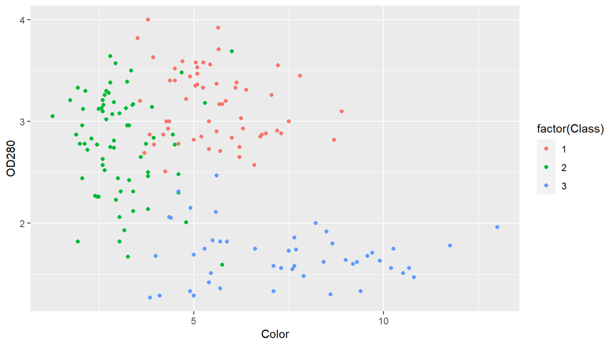

```r
# yes, we could see some *clear boundaries between the
# three class, though there a exists some outlier points in
# each class.
ggplot(data = wine_train, aes(x = Color, y = OD280, color = factor(Class))) +
    geom_point()
```

#### Implementation of Classifiers for Color and OD280

```r
# multinomial logistic regression
wine_train_factored <- wine_train
wine_train_factored$Class <- factor(wine_train_factored$Class)
multiLogistic_classifier <- multinom(Class ~ Color + OD280, data = wine_train_factored)
# LDA
LDA_classifier <- lda(Class ~ Color + OD280, data = wine_train)
# QDA
QDA_classifier <- qda(Class ~ Color + OD280, data = wine_train)
# Naive Bayes classifier: Gaussian naive bayes we won't
# apply KDE naive bayes here since the sample size is
# relatively small
naiveBayes_x <- data.frame(color = wine_train$Color, OD280 = wine_train$OD280)
naiveBayes_y <- as.character(wine_train$Class)
naiveBayes_classifier_F <- naive_bayes(as.character(Class) ~
    Color + OD280, data = wine_train, usekernel = FALSE)
```

#### grid evaluation and minimun bounding box

From the graphs below, we could see that the decision boundary is approximately the same over all classifiers.The QDA and naive bayes classifier might doing better on capturing the true decision boundary, as both have quadratic shape of boundries.

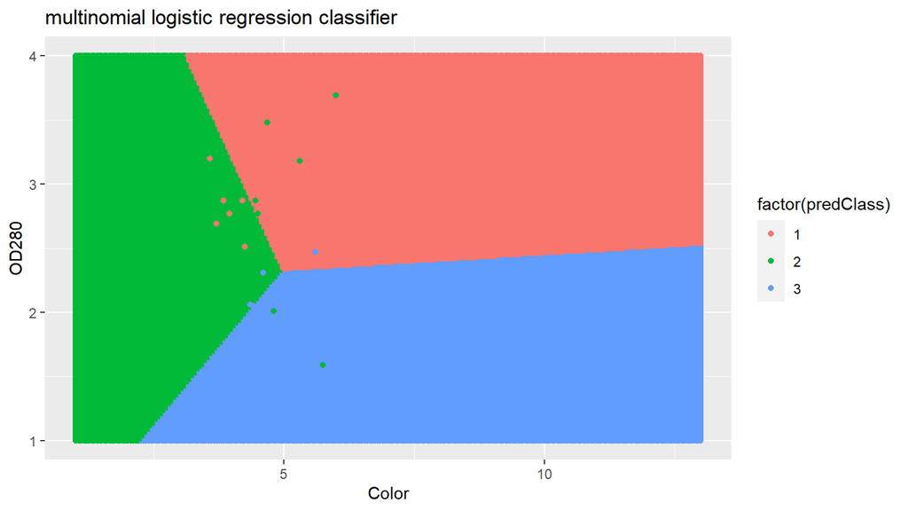

```r
# grid evaluation preparation: build dataframe for full
# range Color[1:13] and OD280[1:4]
test_color <- seq(1, 13, 0.05)
test_OD280 <- seq(1, 4, 0.01)
wine_test_df_pre <- expand.grid(test_color, test_OD280)
wine_test_df <- data.frame(Color = wine_test_df_pre$Var1, OD280 = wine_test_df_pre$Var2)
# prediction from based on each classifier multinomial
# logistic regression
multiLogistic_pred <- data.frame(Color = wine_test_df$Color,
    OD280 = wine_test_df$OD280, predClass = predict(multiLogistic_classifier,
        newdata = wine_test_df))
ggplot(data = multiLogistic_pred, aes(x = Color, y = OD280, color = factor(predClass))) +
    geom_point() + labs(title = "multinomial logistic regression classifier") +
    geom_point(data = wine_train, aes(x = Color, y = OD280, color = factor(Class)))
```

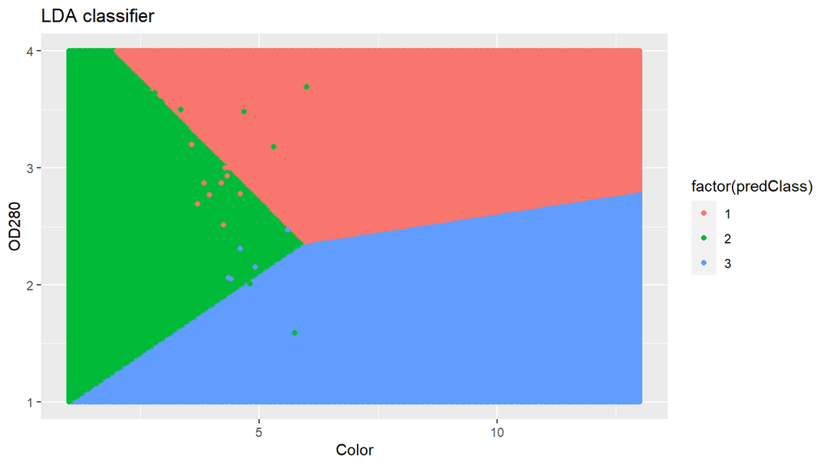

```r
# LDA
LDA_classifier_pred <- data.frame(Color = wine_test_df$Color,
    OD280 = wine_test_df$OD280, predClass = predict(LDA_classifier,
        wine_test_df)$class)
ggplot(data = LDA_classifier_pred, aes(x = Color, y = OD280,
    color = factor(predClass))) + geom_point() + labs(title = "LDA classifier") +
    geom_point(data = wine_train, aes(x = Color, y = OD280, color = factor(Class)))
```

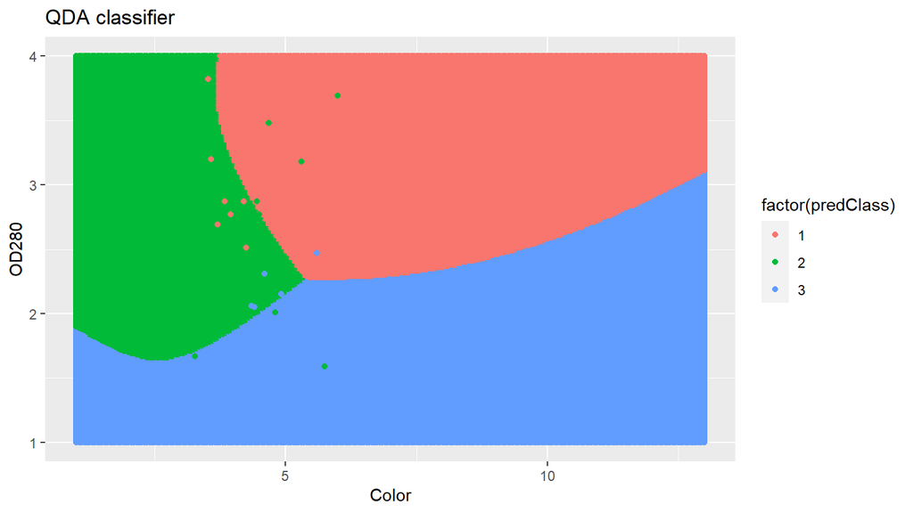

```r
# QDA
QDA_classifier_pred <- data.frame(Color = wine_test_df$Color,
    OD280 = wine_test_df$OD280, predClass = predict(QDA_classifier,
        wine_test_df)$class)
ggplot(data = QDA_classifier_pred, aes(x = Color, y = OD280,
    color = factor(predClass))) + geom_point() + labs(title = "QDA classifier") +
    geom_point(data = wine_train, aes(x = Color, y = OD280, color = factor(Class)))
```

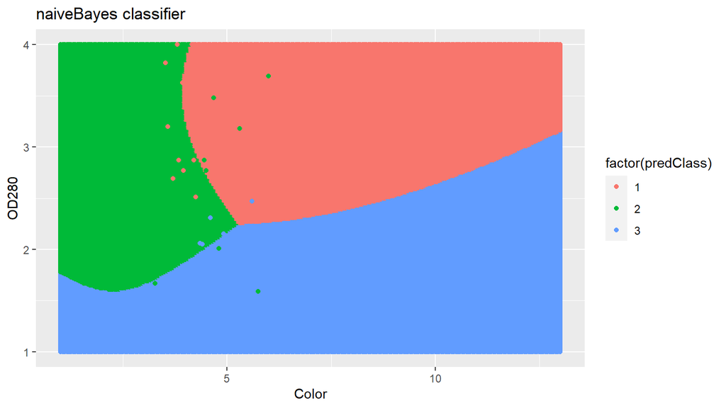

```r
# Naive Bayes classifier: Gaussian naive bayes
naiveBayes_classifier_pred <- data.frame(Color = wine_test_df$Color,
    OD280 = wine_test_df$OD280, predClass = predict(naiveBayes_classifier_F,
        wine_test_df, type = "class"))
# predict(naiveBayes_classifier, wine_test_df, type=
# 'prob')
ggplot(data = naiveBayes_classifier_pred, aes(x = Color, y = OD280,
    color = factor(predClass))) + geom_point() + labs(title = "naiveBayes classifier") +
    geom_point(data = wine_train, aes(x = Color, y = OD280, color = factor(Class)))
```

### Part 2 (15 points)

#### 10-fold estimate of the deviance and the misclassification rate over all variables

The misclassification rates for all classifiers are quite close to one another(maybe they are slightly different if we have more decimal digits but they looks really the same with what we got here). From the deviance perspect, we could see that QDA performs the best here(with LDA have a bit higher deviance), while multinomial logistic regression classifier have a relatively huge deviance.[but also do notice that how the deviance enlarge the differences among the models]

```r
classifier_kfold_checker <- function(check) {
    # data recode & prep
    data <- wine_train  # for other models
    data$Class <- factor(data$Class)
    # split wine_train randomly into 10-fold
    set.seed(1234)
    folds <- create_folds(seq(1, nrow(data)), k = 10, type = "basic")
    # Deviance and Misclass Prop holder
    kf_deviance <- c()
    kf_misclass <- c()
    for (i in 1:length(folds)) {
        if (check == "multiLog") {
            multiLogMod <- multinom(Class ~ ., data = data[folds[[i]],
                ])
            preds <- predict(multiLogMod, newdata = data[-folds[[i]],
                ], type = "probs")
        } else if (check == "LDA") {
            LDA_classifier <- lda(Class ~ ., data = data[folds[[i]],
                ])
            preds <- predict(LDA_classifier, data[-folds[[i]],
                ])$posterior
        } else if (check == "QDA") {
            QDA_classifier <- qda(Class ~ ., data = data[folds[[i]],
                ])
            preds <- predict(QDA_classifier, data[-folds[[i]],
                ])$posterior
        } else if (check == "NB") {
            naiveBayes_classifier <- naive_bayes(as.character(Class) ~
                ., data = data, usekernel = FALSE)
            temp_test_pre <- data[-folds[[i]], ]
            temp_test <- data.frame(temp_test_pre[, -1])
            preds <- predict(naiveBayes_classifier, temp_test,
                type = "prob")
        }
        # Deviance
        kf_deviance[i] <- -2 * sum(log(rowSums(model.matrix(~0 +
            data$Class[-folds[[i]]]) * preds)))
        # Proportion Misclassified
        kf_misclass[i] <- mean(round(preds) != data$Class[-folds[[i]]])
    }
    return(c(mean(kf_deviance), mean(kf_misclass)))
}
multiLog <- classifier_kfold_checker("multiLog")
LDA <- classifier_kfold_checker("LDA")
QDA <- classifier_kfold_checker("QDA")
NB <- classifier_kfold_checker("NB")
result <- data.frame(model = c("multiLog", "LDA", "QDA", "NB"),
    deviance = c(multiLog[1], LDA[1], QDA[1], NB[1]), misclass = c(multiLog[2],
        LDA[2], QDA[2], NB[2]))
result
```

| model | deviance | misclass |
| --- | --- | --- |
| multiLog | 110.3131536 | 0.8893519 |
| LDA | 0.9870861 | 0.8893519 |
| QDA | 0.8008831 | 0.8893519 |
| NB | 1.8183568 | 0.8893519 |

### Part 3

Both NB and QDA can be viewed as methods trying to maximize the log odds of posterior probability $\log( \frac{Pr(Y=k | X=x)}{Pr(Y=K | X=x)})$ with different assumptions. QDA relies on the multivariate normal density (MND) assumption where, for each class, the predictors are drawn from a multivariate normal density function. In other words, QDA assumes that the marginal distribution of predictors are normal. With this assumption, QDA models the log value in a quadratic way in the sense that it allows interaction of pairs of predictors. NB relies on the assumption of independence among predictors and thus doesn’t allow interaction terms. NB models the log value in a generative additive way, and thus is more flexible. From a loss perspective, NB is likely to outperform QDA when the predictor dependencies are not very important in discriminating classes, as QDA has the advantage of capturing such dependencies but is not very flexible in functional forms, while NB is more flexible in an additive way but does not model any interactions among predictors. In the MLE calculated above with MND assumption required by QDA, we can see that the $\hat{\Sigma}$ is a matrix whose size is determined by the length of predictors vector. More specifically, $\hat{\Sigma}$ matrix is a $P \times P$ covariance matrix, where $P$ is the number of predictors. Even though there are $p \times \frac{P-1}{2}$ free parameters due to symmatry of the variance-covariance matrix, when $P$ gets too large, the computation of $\hat{\Sigma}$ can still be very costly. Therefore, from a computational perspective, when there are too many predictors, NB is likely to outperform QDA.